# Count_GAMs

CVM

8/12/2021

Install the necessary packages. Note that I have hidden the output of the download package codesfor brevity, but you can still see the source code in the knitted file.

```r
#for organizing data
if(!require(tidyverse)) install.packages(pkgs = "tidyverse", repos = "http://cran.us.r-project.org")
```

```r
library(tidyverse)

if(!require(dplyr)) install.packages(pkgs = "dplyr", repos = "http://cran.us.r-project.org")
library(dplyr)

#for plotting
if(!require(ggplot2)) install.packages(pkgs = "ggplot2", repos = "http://cran.us.r-project.org")
library(ggplot2)

#for optimizing loess curve
if(!require(fANCOVA)) install.packages(pkgs = "fANCOVA", repos = "http://cran.us.r-project.org")
library(fANCOVA)

#for making the plots look better in pubs
if(!require(cowplot)) install.packages(pkgs = "cowplot", repos = "http://cran.us.r-project.org")
library(cowplot)

#for making GAMs
if(!require(mgcv)) install.packages(pkgs = "mgcv", repos = "http://cran.us.r-project.org")
library(mgcv)

#for making tidy model visuals.
if(!require(tidymv)) install.packages(pkgs = "tidymv", repos = "http://cran.us.r-project.org")
library(tidymv)

#for date math.
if(!require(lubridate)) install.packages(pkgs = "lubridate", repos = "http://cran.us.r-project.org")
library(lubridate)

#for vif function
if(!require(car)) install.packages(pkgs = "car", repos = "http://cran.us.r-project.org")
library(car)

#for making neat, AIC tables.
if(!require(AICcmodavg)) install.packages(pkgs = "AICcmodavg", repos = "http://cran.us.r-project.org")
library(AICcmodavg)

#for making glmm neat for pH vs temp.
#if(!require(lme4)) install.packages(pkgs = "lme4", repos = "http://cran.us.r-project.org")
#library(lme4)
```

Import and read the data. Here we will also convert the date to epoch time (# of days since 01/01/1970) so the gam function can read it. We also convert the month variable into numeric decimals. More info about this can be found here. https://fromthebottomoftheheap.net/2014/05/09/modelling-seasonal-data-with-gam/

```r
#reads the file. ASSUMES YOUR DIRECTORY IS SET TO THE FOLDER CONTAINING THIS FILE AND THAT Count_Data.csv IS IN THIS FOLDER.
counts<-read.csv(file="Count Data.csv")
#Ensures that date is viewed as a date format by R
counts$Date <- as.Date(counts$Date,format = "%m/%d/%Y")

elapsed_months <- function(end_date, start_date) {
    ed <- as.POSIXlt(end_date)
    sd <- as.POSIXlt(start_date)
    12 * (ed$year - sd$year) + (ed$mon - sd$mon)
}

counts$Months_Passed <- elapsed_months(counts$Date,"2013-05-22")

#Calculcates a new field called time, used for GAM
counts$time <- as.integer(as.Date(counts$Date, format = "%d/%m/%Y"))
#Converts Habitat to factor
counts$Habitat <- factor(counts$Habitat)
levels(counts$Habitat) <- list(Cobble  = "C", Nostoc = "N", Run = "R")
#Calcualtes Day Of Year which can be used to model seasonality
counts$DOY <- format(counts$Date, "%j")
#calcualtes year
counts$year <- format(counts$Date, "%Y")
```

Now that the data are imported, lets take a quick look.

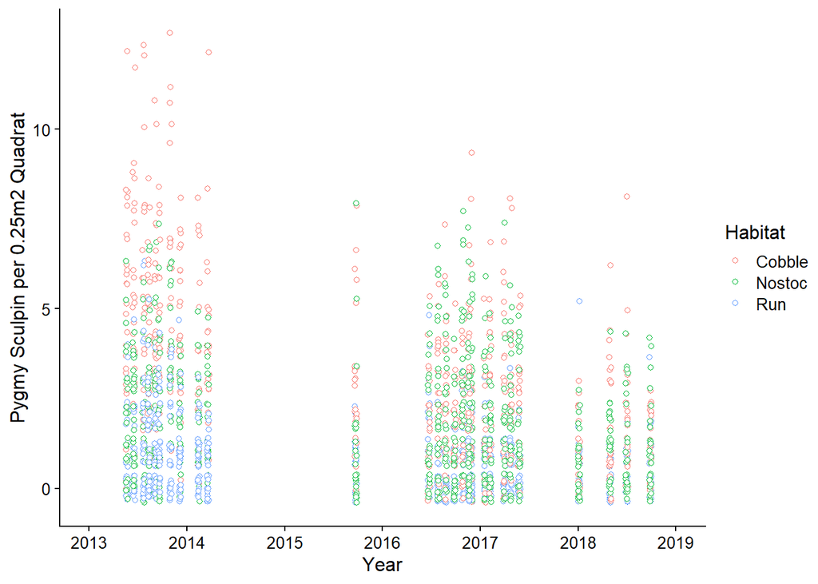

```r
countplot<-
  ggplot(counts,aes(x=Date,y=Count))+
  scale_x_date(date_breaks = "1 years" , date_labels = "%Y",minor_breaks = "1 months")+
  geom_jitter(aes(x=Date,y=Count,color=Habitat),shape=21,fill="white",size=1.5)+
  labs(x='Year',y='Pygmy Sculpin per 0.25m2 Quadrat')+
  scale_x_date(date_breaks = "1 years" , date_labels = "%Y",minor_breaks = "1 months",
    limits = as.Date(c('2013-01-01','2019-01-01')))+
  theme_cowplot(12)
countplot
```

```r
cobble <- subset(counts,COBBLE==1)
cobblemeans<-cobble %>%
  group_by(Months_Passed,Date,Month,time) %>%
  summarize(mean_count=mean(Count),n=n())
run <- subset(counts,RUN==1)
runmeans<- run %>%
  group_by(Months_Passed,Date,Month,time) %>%
  summarize(mean_count=mean(Count),n=n())
nostoc <- subset(counts,NOSTOC==1)
nostocmeans<-nostoc %>%
  group_by(Months_Passed,Date,Month,time) %>%
  summarize(mean_count=mean(Count),n=n())
```

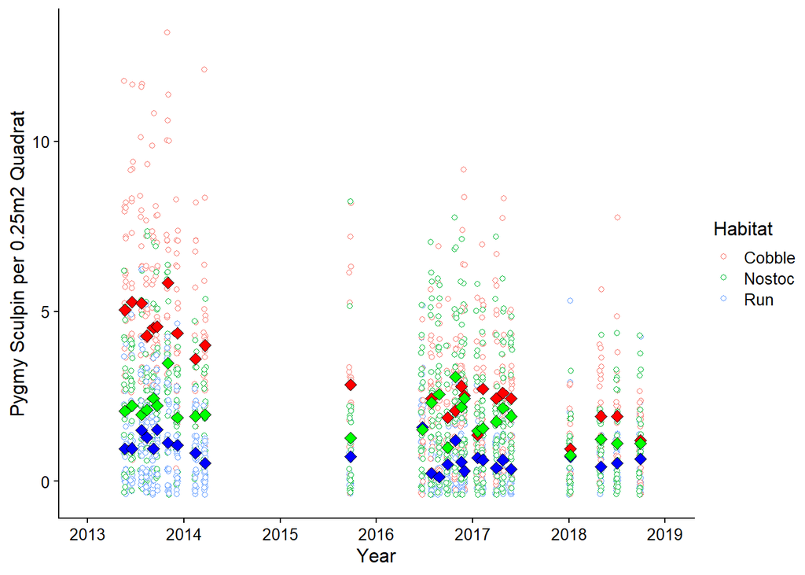

```r
trendplot<- countplot+
  #commenting out the lines per reviewers request, but leaving them here in case we want to add them back in.
  #I feel like the lines show that it is a trend over time and that the observations are dependent on one another.
  #geom_line(data=cobblemeans,aes(x=Date,y=mean_count),shape=23,color="red",size=1)+
  #geom_line(data=runmeans,aes(x=Date,y=mean_count),shape=23,color="blue",size=1)+
  #geom_line(data=nostocmeans,aes(x=Date,y=mean_count),shape=23,color="green",size=1)+
  geom_point(data=cobblemeans,aes(x=Date,y=mean_count),shape=23,color="black",fill="red",size=2.5)+
  geom_point(data=runmeans,aes(x=Date,y=mean_count),shape=23,color="black",fill="blue",size=2.5)+
  geom_point(data=nostocmeans,aes(x=Date,y=mean_count),shape=23,color="black",fill="green",size=2.5)
trendplot
```

Here they are. It looks like there may be a decreasing trend.

Now let’s make a simple model.Because each habitat was sampled multiple times on each date, we will fist summarize by date and habitat. That is, we will calculate the average value for each habitat at each date.

```r
monthly_means<- counts %>%
  group_by(Date,Habitat,Obs,Month,Months_Passed,time,year,COBBLE,NOSTOC,RUN) %>%
  summarize(mean_count=mean(Count),n=n())
monthly_means$NumDays = monthly_means$time-15847
```

I also want to include water temperature and pH, so we’ll have to import the water quality data, and then merge it with monthly means.

First, lets import the data. It is also in this folder which means as long as your directory is set, all you need to do is read the filename. We will import it and do all of the manipulation here so it can be reproduced in the future, if needed. The file ‘Daily Temperatures’ has temp and pH data, so we will just call it ‘wq,’ short for ‘water quality’.

```r
#reads the file. ASSUMES YOUR DIRECTORY IS SET TO THE FOLDER CONTAINING THIS FILE AND THAT Daily Temperatures.csv IS IN THIS FOLDER.
wq<-read.csv(file="Daily Temperatures.csv")
#ensure Date is recognized as a date
wq$Date<-as.Date(wq$Date,format = "%m/%d/%Y")
#calcualte the month so we can summarize by month
wq<- wq %>%
  mutate(month = format(Date, "%m"),year = format(Date, "%Y"))
#Now calucalting elapsed months which is equivalent to Months_Passed in the count data.
elapsed_months <- function(end_date, start_date) {
    ed <- as.POSIXlt(end_date)
    sd <- as.POSIXlt(start_date)
    12 * (ed$year - sd$year) + (ed$mon - sd$mon)
    }
wq<-wq %>%
  mutate(monthspassed = elapsed_months(Date,"2005-01-01"))
wq$month<-as.factor(wq$month)
#Now merge to monthly_means. We need to create a date format that is only month-year for the merge to work
monthly_means$mergedate = format(as.Date(monthly_means$Date), "%Y-%m")

monthwq<-wq %>%
  select(monthspassed,year,month,Daily.Temp,pH,) %>%
  group_by(year,month,monthspassed) %>%
  summarize(n= n(),
            avgtemp = mean(Daily.Temp),
            sdtemp=sd(Daily.Temp),
            maxtemps=max(Daily.Temp),
            avgpH=mean(pH),
            sdpH=sd(pH))
monthwq$date <- as.Date(with(monthwq, paste(year, month, "15",sep="-")), "%Y-%m-%d")

monthwq$mergedate = format(as.Date(monthwq$date), "%Y-%m")
datum <- merge(monthly_means,monthwq,by ="mergedate")
#Since I already built models using pH and temp, I'll create colmns using these names isntead of avgtemp and avgpH. I don't want to rename them because 1. rename() is being finicky, 2. I also have models using the old names.)
datum$pH<-datum$avgpH
datum$temp<-datum$avgtemp
```

While we are at it, let’s export these data so we can submit them with the publication. They will be exported to whatever folder your deirectory is set to.

```r
monthwq$date2<-format(monthwq$date,format = "%m/%d/%Y")
write.csv(monthwq, "WQ.csv")
```

Now we are ready to start selecting terms for our model. We want to determine how mean counts change over time, but we also have water temperature and pH data. Both of these have also probably changed over time, so including all three in the model will lead to issues of concurvity (think of concurvity as analogous to collinearity - except here we have a non-linear response curve.)

Because the data are time series, we can probably also expect the data to be autocorrelated. We can account for this with a correlaion term. To start with, lets try a first order autoregressive term. We can examine ACF and PACF plots after the model is made to determine if we need to change the correlation term.

We will use a backwards elimination process, minimizing AIC and removing non significant terms.

```r
ctrl <- list(niterEM = 0, msVerbose = FALSE, optimMethod="L-BFGS-B")
#fist include all terms, except pH(it isn't compatible with corARMA by year, becasue there aren't enought unique values)

m1 <- gamm(mean_count ~ s(Months_Passed, by = Habitat)+s(avgtemp)+s(avgpH)+s(Month, bs = "cc", k =12)+Habitat,
            data = datum, correlation = corARMA(form = ~ 1|year.x, p = 1),
            control = ctrl)
summary(m1$gam)
```

```
##
## Family: gaussian
## Link function: identity
##
## Formula:
## mean_count ~ s(Months_Passed, by = Habitat) + s(avgtemp) + s(avgpH) +
##     s(Month, bs = "cc", k = 12) + Habitat
##
## Parametric coefficients:
##               Estimate Std. Error t value Pr(>|t|)
## (Intercept)    3.06355    0.09222   33.22   <2e-16 ***
## HabitatNostoc -1.15833    0.10539  -10.99   <2e-16 ***
## HabitatRun    -2.31980    0.10831  -21.42   <2e-16 ***
## ---
## Signif. codes:  0 '***' 0.001 '**' 0.01 '*' 0.05 '.' 0.1 ' ' 1
##
## Approximate significance of smooth terms:
##                                      edf Ref.df       F p-value
## s(Months_Passed):HabitatCobble 1.000e+00  1.000 132.887 < 2e-16 ***
## s(Months_Passed):HabitatNostoc 2.203e+00  2.203   7.450 0.00117 **
## s(Months_Passed):HabitatRun    1.000e+00  1.000   5.186 0.02574 *
## s(avgtemp)                     1.000e+00  1.000   0.118 0.73167
## s(avgpH)                       1.000e+00  1.000   0.371 0.54448
## s(Month)                       4.677e-08 10.000   0.000 0.47958
## ---
## Signif. codes:  0 '***' 0.001 '**' 0.01 '*' 0.05 '.' 0.1 ' ' 1
##
## R-sq.(adj) =   0.86
##   Scale est. = 0.21585   n = 81
```

```r
concurvity(m1$gam)
```

```
##          para s(Months_Passed):HabitatCobble s(Months_Passed):HabitatNostoc
## worst       1                              1                              1
## observed    1                              1                              1
## estimate    1                              1                              1
##          s(Months_Passed):HabitatRun s(avgtemp) s(avgpH) s(Month)
## worst                              1          1        1        1
## observed                           1          1        1        1
## estimate                           1          1        1        1
```

Month, which I included to address seasonality is not significant. Neither are avgtemp or avgpH. We can also see there is concurvity. Since concurvitry can bias estimates, lets address that before dealing with month. I suspect both pH and temp cause concurvity with time, because they both changed over time. pH and Temp are also often related in aquatic systems. In reality, all of them probably contribute to Pygmy Sculpin counts, but for an accurate model we on;y want to include the term that explains the most variation. We’ll create a new model without avgtemp (because it is the lease significant) and then compare it with the original model.

```r
m2 <- gamm(mean_count ~ s(Months_Passed, by = Habitat,k=12)+s(avgpH)+s(Month, bs = "cc", k =12)+Habitat,
            data = datum, correlation = corARMA(form = ~ 1|year.x, p = 1),
            control = ctrl)
summary(m2$gam)
```

```
##
## Family: gaussian
## Link function: identity
##
## Formula:
## mean_count ~ s(Months_Passed, by = Habitat, k = 12) + s(avgpH) +
##     s(Month, bs = "cc", k = 12) + Habitat
##
## Parametric coefficients:
##               Estimate Std. Error t value Pr(>|t|)
## (Intercept)    3.06362    0.09154   33.47   <2e-16 ***
## HabitatNostoc -1.15817    0.10425  -11.11   <2e-16 ***
## HabitatRun    -2.31865    0.10717  -21.64   <2e-16 ***
## ---
## Signif. codes:  0 '***' 0.001 '**' 0.01 '*' 0.05 '.' 0.1 ' ' 1
##
## Approximate significance of smooth terms:
##                                      edf Ref.df       F p-value
## s(Months_Passed):HabitatCobble 1.590e+00  1.590 129.995 < 2e-16 ***
## s(Months_Passed):HabitatNostoc 1.988e+00  1.988   6.988 0.00129 **
## s(Months_Passed):HabitatRun    1.000e+00  1.000   7.115 0.00944 **
## s(avgpH)                       1.000e+00  1.000   0.219 0.64109
## s(Month)                       8.555e-08 10.000   0.000 0.78734
## ---
## Signif. codes:  0 '***' 0.001 '**' 0.01 '*' 0.05 '.' 0.1 ' ' 1
##
## R-sq.(adj) =  0.865
##   Scale est. = 0.21245   n = 81
```

```r
concurvity(m2$gam)
```

```
##          para s(Months_Passed):HabitatCobble s(Months_Passed):HabitatNostoc
## worst       1                       1.000000                      1.0000000
## observed    1                       0.744362                      0.8415244
## estimate    1                       0.771113                      0.7711130
##          s(Months_Passed):HabitatRun s(avgpH)  s(Month)
## worst                      1.0000000 1.000000 1.0000000
## observed                   0.7577938 0.978569 0.9976496
## estimate                   0.7711130 0.977849 0.8249146
```

Now we will put avgtemp back in, and remove avgpH, then we will put avgpH back in and remove month. We will then use AIC tro comapre all of these models. Most likely, the model without acgtemp will be the best, becasue avg temp was least significant.

```r
#pH removed, temp remians.
m3 <- gamm(mean_count ~ s(Months_Passed, by = Habitat,k=20)+s(avgtemp)+s(Month, bs = "cc", k =12)+Habitat,
            data = datum, correlation = corARMA(form = ~ 1|year.x, p = 1),
            control = ctrl)

#month removed, temp and pH remain.
m4 <- gamm(mean_count ~ s(Months_Passed, by = Habitat,k=20)+s(avgtemp)+s(avgpH)+Habitat,
            data = datum, correlation = corARMA(form = ~ 1|year.x, p = 1),
            control = ctrl)

#Now a quick comparison of AIC will tell us which model is among these 4 is best.
anova(m1$lme,m2$lme,m3$lme,m4$lme)
```

```
##        Model df      AIC      BIC    logLik   Test   L.Ratio p-value
## m1$lme     1 16 136.0526 174.3638 -52.02631
## m2$lme     2 14 132.4118 165.9341 -52.20590 1 vs 2 0.3591757  0.8356
## m3$lme     3 14 132.5571 166.0794 -52.27854
## m4$lme     4 15 134.1252 170.0419 -52.06260 3 vs 4 0.4318850  0.5111
```

As suspected, the best model was m2, in which we removed the least significant term, avgtemp. Lets see what it looks like.

```r
summary(m2$gam)
```

```
##
## Family: gaussian
## Link function: identity
##
## Formula:
## mean_count ~ s(Months_Passed, by = Habitat, k = 12) + s(avgpH) +
##     s(Month, bs = "cc", k = 12) + Habitat
##
## Parametric coefficients:
##               Estimate Std. Error t value Pr(>|t|)
## (Intercept)    3.06362    0.09154   33.47   <2e-16 ***
## HabitatNostoc -1.15817    0.10425  -11.11   <2e-16 ***
## HabitatRun    -2.31865    0.10717  -21.64   <2e-16 ***
## ---
## Signif. codes:  0 '***' 0.001 '**' 0.01 '*' 0.05 '.' 0.1 ' ' 1
##
## Approximate significance of smooth terms:
##                                      edf Ref.df       F p-value
## s(Months_Passed):HabitatCobble 1.590e+00  1.590 129.995 < 2e-16 ***
## s(Months_Passed):HabitatNostoc 1.988e+00  1.988   6.988 0.00129 **
## s(Months_Passed):HabitatRun    1.000e+00  1.000   7.115 0.00944 **
## s(avgpH)                       1.000e+00  1.000   0.219 0.64109
## s(Month)                       8.555e-08 10.000   0.000 0.78734
## ---
## Signif. codes:  0 '***' 0.001 '**' 0.01 '*' 0.05 '.' 0.1 ' ' 1
##
## R-sq.(adj) =  0.865
##   Scale est. = 0.21245   n = 81
```

```r
concurvity(m2$gam)
```

```
##          para s(Months_Passed):HabitatCobble s(Months_Passed):HabitatNostoc
## worst       1                       1.000000                      1.0000000
## observed    1                       0.744362                      0.8415244
## estimate    1                       0.771113                      0.7711130
##          s(Months_Passed):HabitatRun s(avgpH)  s(Month)
## worst                      1.0000000 1.000000 1.0000000
## observed                   0.7577938 0.978569 0.9976496
## estimate                   0.7711130 0.977849 0.8249146
```

We still have two terms that are not significant, and concurvity. Let’s keep working backwards. Again, we will create new models, each with one of the non-significant terms removed, then we will compare them all with AIC.

```r
#remove months
m5 <- gamm(mean_count ~ s(Months_Passed, by = Habitat,k=12)+s(avgpH)+Habitat,
            data = datum, correlation = corARMA(form = ~ 1|year.x, p = 1),
            control = ctrl)
#remove avgpH
m6 <- gamm(mean_count ~ s(Months_Passed, by = Habitat,k=12)+s(Month, bs = "cc", k =12)+Habitat,
            data = datum, correlation = corARMA(form = ~ 1|year.x, p = 1),
            control = ctrl)
#Compare with ACI
anova(m2$lme,m5$lme,m6$lme)
```

```
##        Model df      AIC      BIC    logLik   Test    L.Ratio p-value
## m2$lme     1 14 132.4118 165.9341 -52.20590
## m5$lme     2 13 130.4118 161.5396 -52.20590 1 vs 2 0.00000003  0.9999
## m6$lme     3 12 128.5403 157.2737 -52.27016 2 vs 3 0.12852918  0.7200
```

m6, the model without avgpH has the best fit. This is a good example of why we should not take shortcuts and jsut remove the term with the highest p-value. If we had done that, we would have ended up with model 5. Let’s see how m6 looks.

```r
summary(m6$gam)
```

```
##
## Family: gaussian
## Link function: identity
##
## Formula:
## mean_count ~ s(Months_Passed, by = Habitat, k = 12) + s(Month,
##     bs = "cc", k = 12) + Habitat
##
## Parametric coefficients:
##               Estimate Std. Error t value Pr(>|t|)
## (Intercept)    3.06381    0.09141   33.52   <2e-16 ***
## HabitatNostoc -1.15798    0.10431  -11.10   <2e-16 ***
## HabitatRun    -2.31787    0.10722  -21.62   <2e-16 ***
## ---
## Signif. codes:  0 '***' 0.001 '**' 0.01 '*' 0.05 '.' 0.1 ' ' 1
##
## Approximate significance of smooth terms:
##                                      edf Ref.df       F p-value
## s(Months_Passed):HabitatCobble 1.839e+00  1.839 109.947 < 2e-16 ***
## s(Months_Passed):HabitatNostoc 1.859e+00  1.859   5.834 0.00311 **
## s(Months_Passed):HabitatRun    1.000e+00  1.000   6.952 0.01022 *
## s(Month)                       9.537e-08 10.000   0.000 0.82825
## ---
## Signif. codes:  0 '***' 0.001 '**' 0.01 '*' 0.05 '.' 0.1 ' ' 1
##
## R-sq.(adj) =  0.867
##   Scale est. = 0.21198   n = 81
```

```r
concurvity(m6$gam)
```

```
##               para s(Months_Passed):HabitatCobble
## worst    0.6666667                     0.99552748
## observed 0.6666667                     0.04285799
## estimate 0.6666667                     0.05865122
##          s(Months_Passed):HabitatNostoc s(Months_Passed):HabitatRun  s(Month)
## worst                        0.99552748                  0.99552748 0.9985047
## observed                     0.06508254                  0.04573899 0.9719876
## estimate                     0.05865122                  0.05865122 0.4154485
```

The model is looking better, but there is still some concurvity and month is still not significant. Let’s reomve it and see what happens to the AIC.

```r
m7 <- gamm(mean_count ~ s(Months_Passed, by = Habitat,k=12)+Habitat,
            data = datum, correlation = corARMA(form = ~ 1|year.x, p = 1),
            control = ctrl)
anova(m6$lme,m7$lme)
```

```
##        Model df      AIC      BIC    logLik   Test      L.Ratio p-value
## m6$lme     1 12 128.5403 157.2737 -52.27016
## m7$lme     2 11 126.5403 152.8793 -52.27016 1 vs 2 3.222354e-08  0.9999
```

m7, the model without month is the best fit. Note that the AIC went down by 2 and so df decreased by 1. THe penalty for an extra term is 2AIC, so the improvement offered by month must have been negligible. Let’s see how m7 looks.

```r
summary(m7$gam)
```

```
##
## Family: gaussian
## Link function: identity
##
## Formula:
## mean_count ~ s(Months_Passed, by = Habitat, k = 12) + Habitat
##
## Parametric coefficients:
##               Estimate Std. Error t value Pr(>|t|)
## (Intercept)    3.06381    0.09141   33.52   <2e-16 ***
## HabitatNostoc -1.15798    0.10431  -11.10   <2e-16 ***
## HabitatRun    -2.31787    0.10722  -21.62   <2e-16 ***
## ---
## Signif. codes:  0 '***' 0.001 '**' 0.01 '*' 0.05 '.' 0.1 ' ' 1
##
## Approximate significance of smooth terms:
##                                  edf Ref.df       F p-value
## s(Months_Passed):HabitatCobble 1.839  1.839 109.951 < 2e-16 ***
## s(Months_Passed):HabitatNostoc 1.860  1.860   5.835 0.00311 **
## s(Months_Passed):HabitatRun    1.000  1.000   6.952 0.01022 *
## ---
## Signif. codes:  0 '***' 0.001 '**' 0.01 '*' 0.05 '.' 0.1 ' ' 1
##
## R-sq.(adj) =  0.867
##   Scale est. = 0.21198   n = 81
```

```r
concurvity(m7$gam)
```

```
##               para s(Months_Passed):HabitatCobble
## worst    0.6666667                   1.021945e-19
## observed 0.6666667                   2.543777e-28
## estimate 0.6666667                   7.623935e-23
##          s(Months_Passed):HabitatNostoc s(Months_Passed):HabitatRun
## worst                      1.021811e-19                1.021900e-19
## observed                   2.975606e-27                5.703773e-29
## estimate                   7.624022e-23                7.623601e-23
```

All variables are now significant and concurvity looks alright. This model is looing better but we still need to consider look at residuals and autocorrelation.

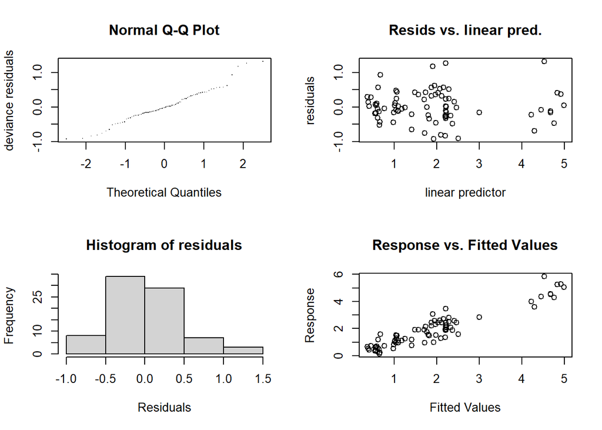

```
##
## 'gamm' based fit - care required with interpretation.
## Checks based on working residuals may be misleading.
## Basis dimension (k) checking results. Low p-value (k-index<1) may
## indicate that k is too low, especially if edf is close to k'.
##
##                                   k'   edf k-index p-value
## s(Months_Passed):HabitatCobble 11.00  1.84    0.71   0.005 **
## s(Months_Passed):HabitatNostoc 11.00  1.86    0.71   0.005 **
## s(Months_Passed):HabitatRun    11.00  1.00    0.71  <2e-16 ***
## ---
## Signif. codes:  0 '***' 0.001 '**' 0.01 '*' 0.05 '.' 0.1 ' ' 1
```

```r
gam.check(m7$gam)
```

There appears to be some autocorrelation, but otherwise the residuals look good. We’ll see if the autocorrelation is significant next. Also, note that on the gam check, p-values are low but k is not close to edf. Based on the residuals, I think this model will work, as long as the autocorrelation is not significant. So, let’s look.

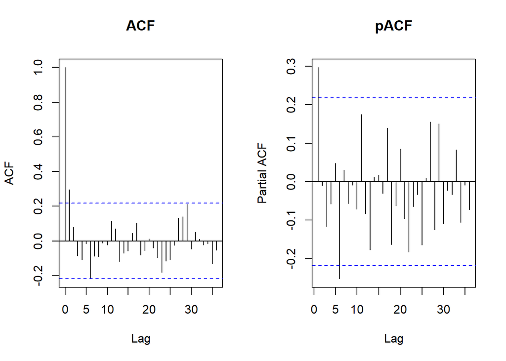

```r
layout(matrix(1:2, ncol = 2))
acf(resid(m7$gam), lag.max = 36, main = "ACF")
pacf(resid(m7$gam), lag.max = 36, main = "pACF")
```

```r
layout(1)
```

The blue lines represent significance thresholds. Overall, the model does not have much significant autocorrelation, but a second order autocorrelation term may be warranted.

```r
m8 <- gamm(mean_count ~ s(Months_Passed, by = Habitat,k=12)+Habitat,
            data = datum, correlation = corARMA(form = ~ 1|year.x, p = 2),
            control = ctrl)
anova(m7$lme,m8$lme)
```

```
##        Model df      AIC      BIC    logLik   Test   L.Ratio p-value
## m7$lme     1 11 126.5403 152.8793 -52.27016
## m8$lme     2 12 128.3883 157.1217 -52.19416 1 vs 2 0.1519961  0.6966
```

First the response curves.

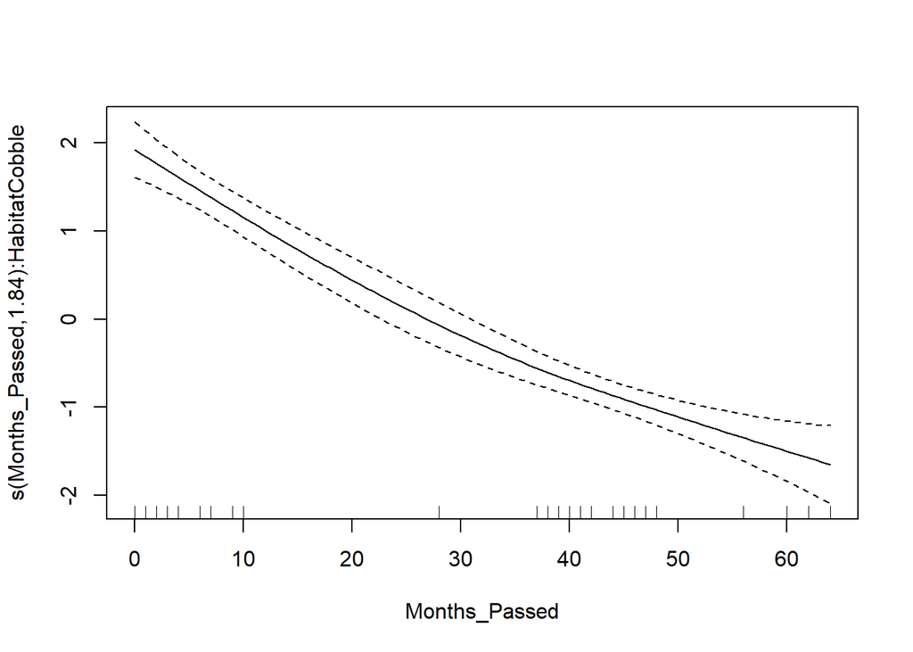

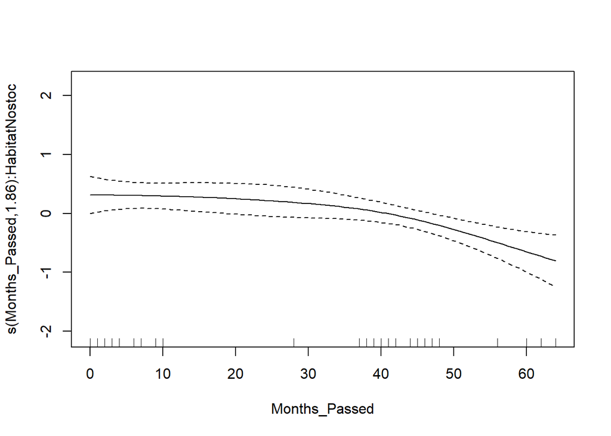

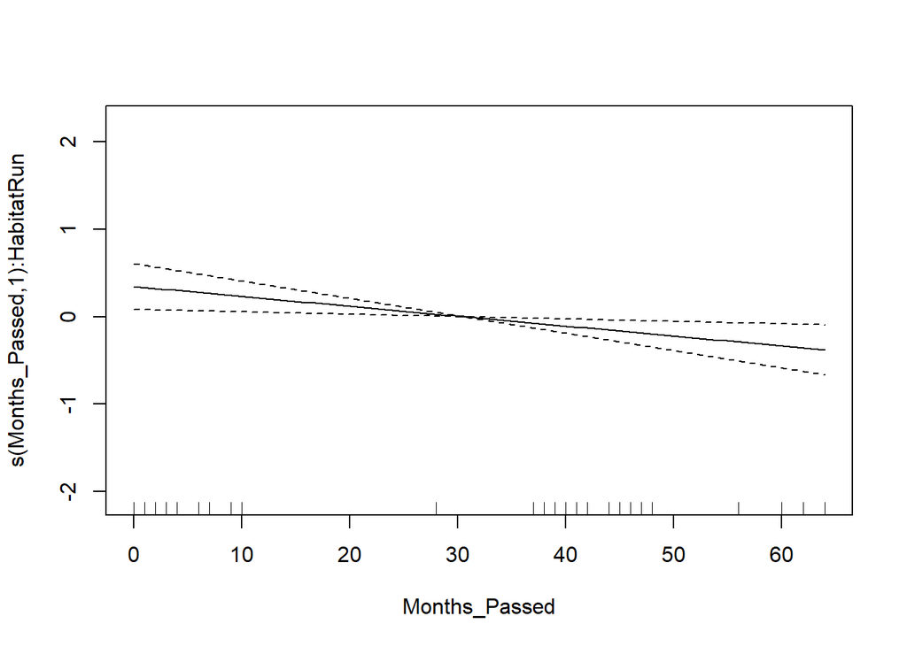

```r
plot(m7$gam)
```

It looks like there is a slight decrease in all habitats, but cobble had the most severe decrease.

Let’s make the plot nicer. Also note that the predictions from the model will mirror the response curves, becasue only one term, months_passed (time), was significant. Normally, the predictions for GAMS is the sum off all response curves.

I used months passed to measure time, but that doesn’t graph as neatly. So, I’ll use the same model, but with days as the units for the x-axis.

```r
m7pred <- gamm(mean_count ~ s(time, by = Habitat)+Habitat,
            data = datum, correlation = corARMA(form = ~ 1|year.x, p = 1),
            control = ctrl)

predictCount <- predict_gam(m7pred$gam)
#Convert epoch time to date for graphing
predictCount$date <- as.Date(predictCount$time,origin = "1970-01-01")
```

Note - to appease the reviewers, I’ve added this to scale_x_date. limits = as.Date(c(‘2013-01-01’,‘2019-01-01’)). I think it looks better without because it had less white space at low values of x.

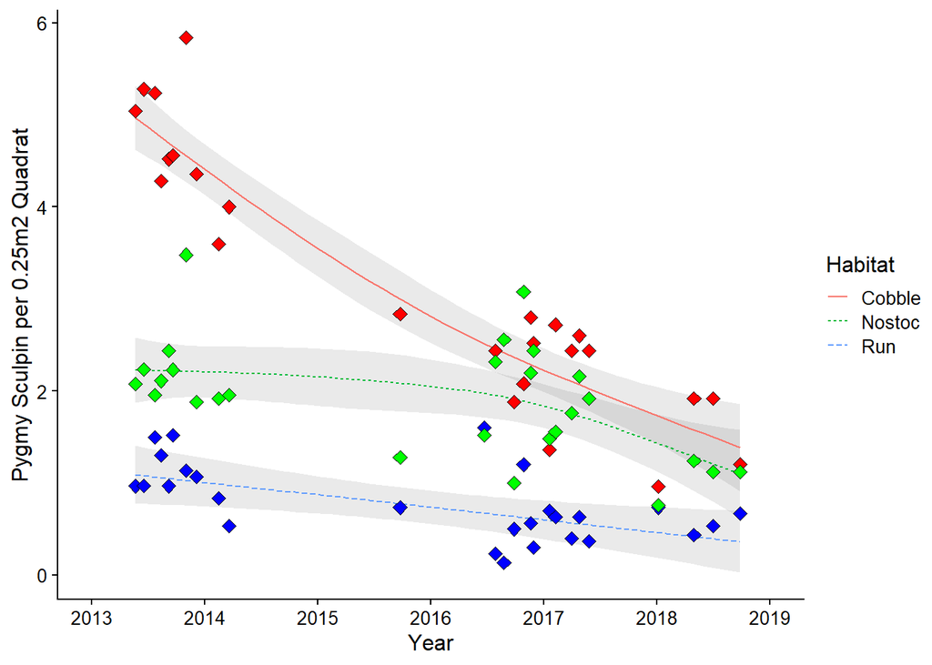

```r
fitstm7 <-
  ggplot(predictCount,aes(date, fit)) +
  geom_smooth_ci(Habitat)+
  geom_point(data=cobblemeans,aes(x=Date,y=mean_count),shape=23,color="black",fill="red",size=2.5)+
  geom_point(data=runmeans,aes(x=Date,y=mean_count),shape=23,color="black",fill="blue",size=2.5)+
  geom_point(data=nostocmeans,aes(x=Date,y=mean_count),shape=23,color="black",fill="green",size=2.5)+
  scale_x_date(date_breaks = "1 years" , date_labels = "%Y",limits = as.Date(c('2013-01-01','2019-01-01')))+
  labs(x='Year',y='Pygmy Sculpin per 0.25m2 Quadrat')+
  theme_cowplot(12)
fitstm7
```

And here is the plot. The cobble, where Pygym Sculpin are most dense is seeing the biggest decrease. I’m not sure why. In the future we may need water quality data on a smaller scale. Perhaps the cobble habitat, which has less water turnover, is warming faster.